# Question 5

# Introduction

For this question we will be looking at the database of app downloads from Google to see what encourages people to download a particular app.

# Analysis

Firstly I need to import the data.

Ok so based on the data I want to see what are the most downloaded types of apps, therefore I will look at the number of installations per application type. First I need to change this line to be numeric values.

Ok so now I want to see which app categories are the most used. In order to do that I am going to do a scatter plot which shows the average number of reviews of each app category, as well as the average number of downloads received by each category.

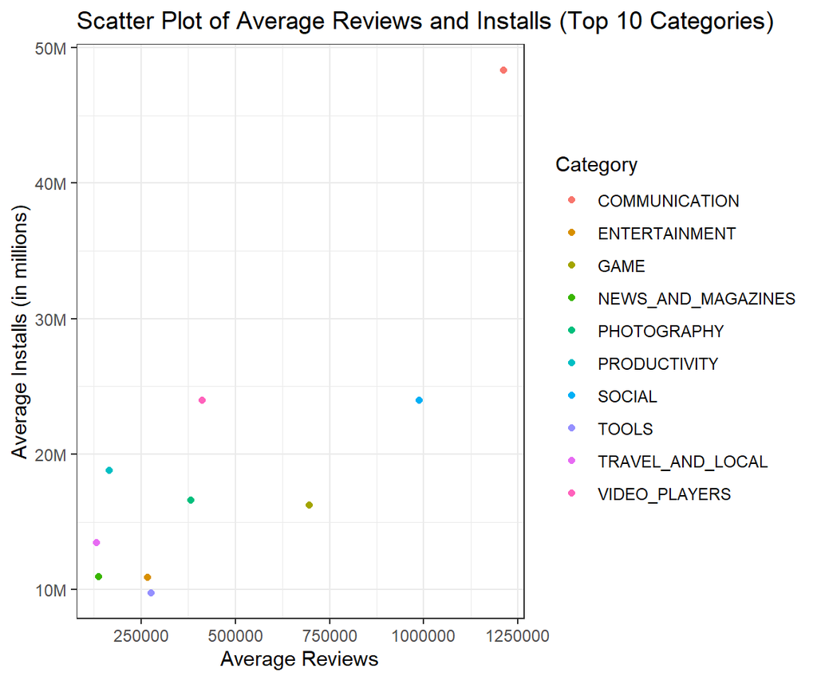

So we know what is the most used types of apps and most reviewed. However an important factor when understanding the reviews of a particular is app is whether or not they are positive. Apps with more positive reviews are likely to be used more frequently, so using the user review data set, we can compare the percentage of positive, negative and neutral reviews for each app category.

Ok now we must merge the category column to be assigned with therespective app in the Review data set.

Ok so now using the merged data we can work out the percentage of each type of review in each category.

| Category | pos_percent | neg_percent | neu_percent |
| --- | --- | --- | --- |
| COMMUNICATION | 62.69478 | 20.62328 | 16.681943 |
| ENTERTAINMENT | 58.26226 | 25.53305 | 16.204691 |
| GAME | 58.10628 | 37.52823 | 4.365498 |
| NEWS_AND_MAGAZINES | 57.57403 | 29.32802 | 13.097950 |
| PHOTOGRAPHY | 65.70281 | 20.40161 | 13.895582 |
| PRODUCTIVITY | 68.83657 | 18.74423 | 12.419206 |
| SOCIAL | 54.08367 | 26.19522 | 19.721116 |
| TOOLS | 60.37216 | 17.64300 | 21.984838 |
| TRAVEL_AND_LOCAL | 60.90652 | 21.34089 | 17.752597 |
| VIDEO_PLAYERS | 57.40181 | 25.07553 | 17.522659 |